# Image Segmentation, Morphological Operators & Shape Analysis

**Student Name:** Andrés Jauch  
**Semester Term:** FS26

## Introduction & Use Case

In this third task, I want to segment the landmass of Hispaniola from the surrounding ocean.

To do this, I will use a Green minus Blue channel difference. Since the vegetation on land reflects green and water absorbs it, while water reflects blue, the difference image highlights the land really well. I will normalize this difference and use Otsu"s thresholding to separate land from water automatically.

To handle clouds, which get misclassified as land because they are bright, I will build an HSV cloud mask. I noticed that clouds over the ocean are cool-toned, while the soil is warm-toned, so I can use a Red-minus-Blue channel check to filter out clouds without cutting into dry land. If the image is hazy, I'll fall back to a safer, less aggressive cloud threshold so I don"t accidentally mask out the haze.

After binarization, I will use morphological opening and closing to clean up noise, keep only the largest connected component (the main island), and fill all internal lakes and cloud shadows. Then, I will draw the final coastline using a morphological gradient, calculate Area and Perimeter stats, and create a clean skeleton of the island. Lastly, I'll compare the results under haze using the Intersection over Union (IoU) metric.

```python
import cv2
import numpy as np
import matplotlib.pyplot as plt
import pandas as pd
```

## Technical Implementation

### Image loading and Green-Blue difference

I load the image, resize it to 800px width for speed, and split the channels to calculate the Green-Blue difference. Normalizing this difference helps suppress water reflections and makes thresholding claener.

```
Otsu's Threshold on Green-Blue Difference: 102.00
```

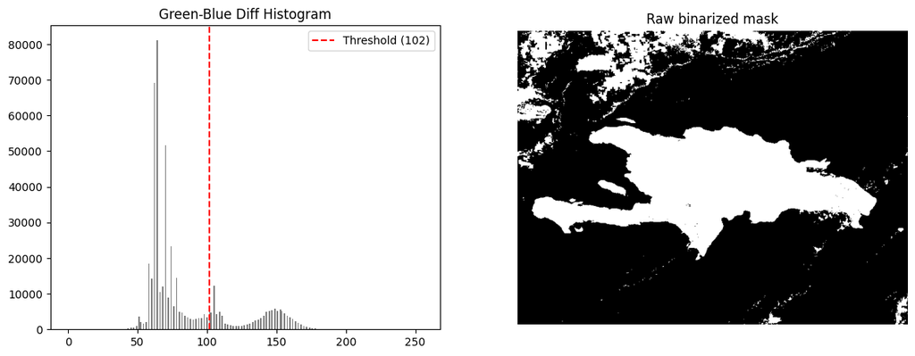

```python
# Load and resize
img_source = cv2.imread("source/satelita_hispaniola.jpg")
if img_source is None:
    raise FileNotFoundError("Couldnt find ../source/satelita_hispaniola.jpg")

target_width = 800
H, W, _ = img_source.shape
target_height = int(target_width * H / W)
img_source = cv2.resize(img_source, (target_width, target_height), interpolation=cv2.INTER_AREA)

img_rgb = cv2.cvtColor(img_source, cv2.COLOR_BGR2RGB)

# Conv to float to compute difference
b, g, r = cv2.split(img_source.astype(np.float32))

# Green-Blue difference highlights vegetation (land) and suppresses water
diff = g - b
diff_norm = ((diff - diff.min()) / (diff.max() - diff.min()) * 255).astype(np.uint8)

# Otsu"s Thresholding on Normalized Difference
otsu_threshold, thresh_mask = cv2.threshold(
    diff_norm, 0, 255, cv2.THRESH_BINARY + cv2.THRESH_OTSU
)
print(f"Otsu's Threshold on Green-Blue Difference: {otsu_threshold:.2f}")

fig, axes = plt.subplots(1, 2, figsize=(14, 5))

# Histogram
axes[0].hist(diff_norm.ravel(), bins=256, color="gray")
axes[0].axvline(otsu_threshold, color="red", linestyle="--", label=f"Threshold ({otsu_threshold:.0f})")
axes[0].set_title("Green-Blue Diff Histogram")
axes[0].legend()

# Mask
axes[1].imshow(thresh_mask, cmap="gray")
axes[1].set_title("Raw binarized mask")
axes[1].axis("off")
plt.show()
```

### Cloud filtering and Morphological tests

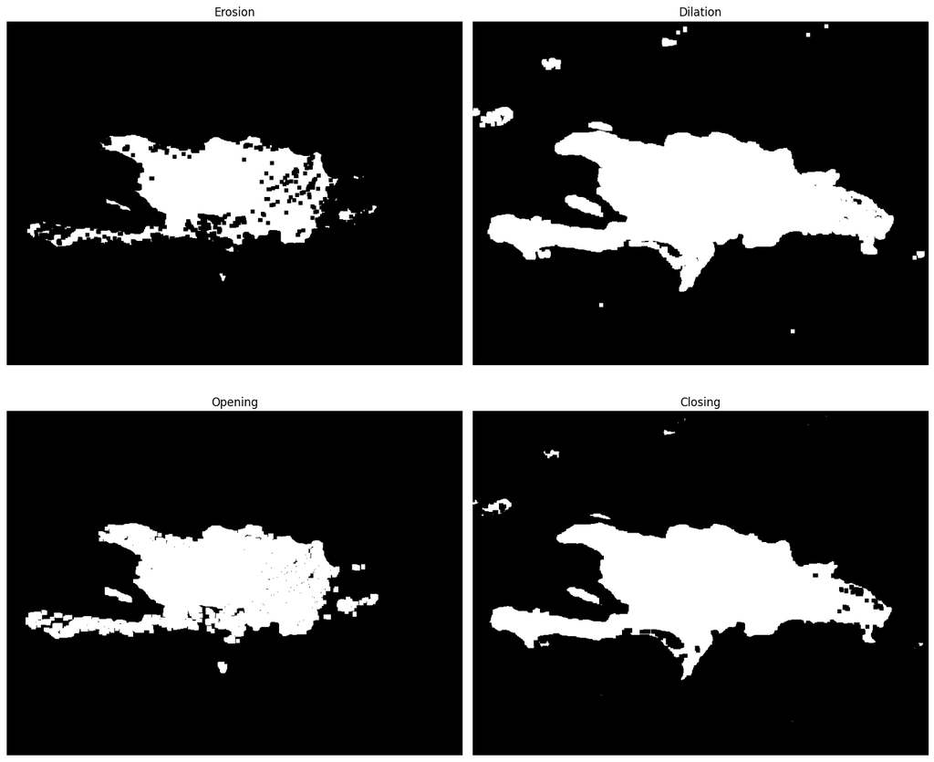

```python
# Identify clouds in HSV color space
hsv = cv2.cvtColor(img_source, cv2.COLOR_BGR2HSV)
h_chan, s_chan, v_chan = cv2.split(hsv)

# Check sharpness to see if image is hazy
gray_temp = cv2.cvtColor(img_source, cv2.COLOR_BGR2GRAY)
sharpness = cv2.Laplacian(gray_temp, cv2.CV_64F).var()

if sharpness < 150:
    # Hazy image: conservative cloud mask to prevent haze from being cut out
    cloud_mask = (v_chan > 140) & (s_chan < 60)
else:
    # Clear image: sensitive cool-toned cloud mask using Red-minus-Blue check
    b_ch, g_ch, r_ch = cv2.split(img_source.astype(np.float32))
    r_minus_b = r_ch - b_ch
    cloud_mask = (v_chan > 55) & (s_chan < 110) & (r_minus_b < 15)

# Filter out clouds from initial binarized mask
thresh_mask_no_clouds = thresh_mask.copy()
thresh_mask_no_clouds[cloud_mask] = 0

kernel = np.ones((7, 7), np.uint8)

mask_erosion = cv2.erode(thresh_mask_no_clouds, kernel, iterations=1)
mask_dilation = cv2.dilate(thresh_mask_no_clouds, kernel, iterations=1)
mask_opening = cv2.morphologyEx(thresh_mask_no_clouds, cv2.MORPH_OPEN, kernel)
mask_closing = cv2.morphologyEx(thresh_mask_no_clouds, cv2.MORPH_CLOSE, kernel)

fig, axes = plt.subplots(2, 2, figsize=(14, 12))

# Erosion
axes[0, 0].imshow(mask_erosion, cmap="gray")
axes[0, 0].set_title("Erosion")
axes[0, 0].axis("off")

#Dilation
axes[0, 1].imshow(mask_dilation, cmap="gray")
axes[0, 1].set_title("Dilation")
axes[0, 1].axis("off")

#Opening
axes[1, 0].imshow(mask_opening, cmap="gray")
axes[1, 0].set_title("Opening")
axes[1, 0].axis("off")

#Closing
axes[1, 1].imshow(mask_closing, cmap="gray")
axes[1, 1].set_title("Closing")
axes[1, 1].axis("off")

plt.tight_layout()
plt.show()
```

### Coastline extraction and island cleaning

After morphological cleaning, I use connected components to find the largest component, which is the main island, and discard any small cloud fragments in the ocean. To get a clean outer boundary without loops around inland lakes or cloud shadows, I'll fill all internal holes. Then, I apply a morphological gradient to get the final coastline outline.

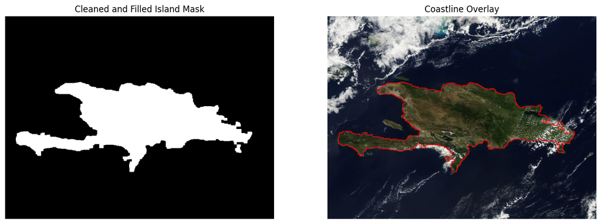

```python
# Clean mask morphologically
mask_cleaned = cv2.morphologyEx(thresh_mask_no_clouds, cv2.MORPH_CLOSE, kernel)
mask_cleaned = cv2.morphologyEx(mask_cleaned, cv2.MORPH_OPEN, kernel)

# Keep only the largest component to filter out ocean clouds
num_labels, labels, stats, centroids = cv2.connectedComponentsWithStats(mask_cleaned)
if num_labels > 1:
    largest_label = np.argmax(stats[1:, cv2.CC_STAT_AREA]) + 1
    mask_largest = (labels == largest_label).astype(np.uint8) * 255
else:
    mask_largest = mask_cleaned

# Fill all internal holes inside the main island
mask_filled = np.zeros(mask_largest.shape, np.uint8)
contours, hierarchy = cv2.findContours(mask_largest, cv2.RETR_CCOMP, cv2.CHAIN_APPROX_SIMPLE)
if contours and hierarchy is not None:
    for i in range(len(contours)):
        # If the contour has no "parent", it"s the border
        if hierarchy[0][i][3] == -1:
            cv2.drawContours(mask_filled, contours, i, 255, -1)
else:
    mask_filled = mask_largest

# Morphological Gradient to get the border of the filled mask
gradient_kernel = cv2.getStructuringElement(cv2.MORPH_RECT, (3, 3))
coastline = cv2.morphologyEx(mask_filled, cv2.MORPH_GRADIENT, gradient_kernel)

img_overlay = img_rgb.copy()
img_overlay[coastline == 255] = [255, 0, 0]

fig, axes = plt.subplots(1, 2, figsize=(15, 7))

# Filled
axes[0].imshow(mask_filled, cmap="gray")
axes[0].set_title("Cleaned and Filled Island Mask")
axes[0].axis("off")

# Overlay
axes[1].imshow(img_overlay)
axes[1].set_title("Coastline Overlay")
axes[1].axis("off")
plt.show()
```

### Area and Perimeter of objects

Before filtering out the small components, I will count all the separated regions in the cleaned mask and compute the area and perimeter of each.

```python
# Perform CC analysis on the cleaned mask
num_labels_cc, labels_cc, stats_cc, centroids_cc = cv2.connectedComponentsWithStats(mask_cleaned)
total_objects = num_labels_cc - 1
print(f"Total Segmented Objects (excluding background): {total_objects}")

areas = []
perimeters = []
for i in range(1, num_labels_cc):
    area = stats_cc[i, cv2.CC_STAT_AREA]
    areas.append(area)

    comp_mask = (labels_cc == i).astype(np.uint8) * 255
    contours_c, _ = cv2.findContours(comp_mask, cv2.RETR_EXTERNAL, cv2.CHAIN_APPROX_SIMPLE)
    if contours_c:
        perimeter = cv2.arcLength(contours_c[0], True)
    else:
        perimeter = 0.0
    perimeters.append(perimeter)

largest_idx = np.argmax(areas)
print(f"Largest Component (Main Island) is Label {largest_idx+1} with Area: {areas[largest_idx]} pixels")
```

```
Total Segmented Objects (excluding background): 4
Largest Component (Main Island) is Label 3 with Area: 81473 pixels
```

### Skeletonization

```
Skeleton Pixels: 1137
```

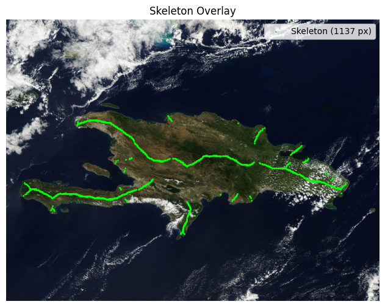

```python
# Smooth the mask to eliminate jagged edge noise for skeletonization
skel_kernel = cv2.getStructuringElement(cv2.MORPH_ELLIPSE, (15, 15))
mask_smoothed = cv2.morphologyEx(mask_filled, cv2.MORPH_OPEN, skel_kernel)
mask_smoothed = cv2.morphologyEx(mask_smoothed, cv2.MORPH_CLOSE, skel_kernel)

skel = np.zeros(mask_smoothed.shape, np.uint8)
img_temp = mask_smoothed.copy()
element = cv2.getStructuringElement(cv2.MORPH_CROSS, (3, 3))

while True:
    eroded = cv2.erode(img_temp, element)
    temp = cv2.dilate(eroded, element)
    temp = cv2.subtract(img_temp, temp)
    skel = cv2.bitwise_or(skel, temp)
    img_temp = eroded.copy()
    if cv2.countNonZero(img_temp) == 0:
        break

skeleton_pixels = cv2.countNonZero(skel)
print(f"Skeleton Pixels: {skeleton_pixels}")

plt.figure(figsize=(10, 6))
plt.imshow(img_rgb)
y_indices, x_indices = np.where(skel == 255)
plt.scatter(x_indices, y_indices, color="lime", s=1, label=f"Skeleton ({skeleton_pixels} px)")
plt.title("Skeleton Overlay")
plt.axis("off")
plt.legend()
plt.show()
```

## Segmentation under Hazy Conditions

I'll wrap my segmentation steps into a single function and run it on the light and heavy haze images to check how well it holds up.

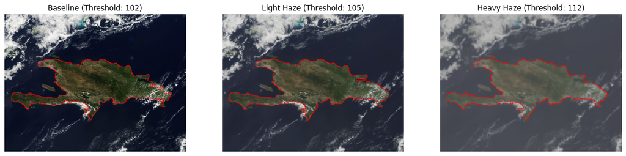

```python
def extract_clean_island_mask(img_bgr):
    # Green - Blue difference
    b_ch, g_ch, r_ch = cv2.split(img_bgr.astype(np.float32))
    diff_ch = g_ch - b_ch
    diff_norm_ch = ((diff_ch - diff_ch.min()) / (diff_ch.max() - diff_ch.min()) * 255).astype(np.uint8)

    # Otsu thresholding
    threshold_val, thresh_m = cv2.threshold(diff_norm_ch, 0, 255, cv2.THRESH_BINARY + cv2.THRESH_OTSU)

    # HSV cloud mask
    hsv_ch = cv2.cvtColor(img_bgr, cv2.COLOR_BGR2HSV)
    h_c, s_c, v_c = cv2.split(hsv_ch)

    # Sharpness check
    gray_ch = cv2.cvtColor(img_bgr, cv2.COLOR_BGR2GRAY)
    sharpness = cv2.Laplacian(gray_ch, cv2.CV_64F).var()

    if sharpness < 150:
        # Hazy: conservative cloud mask
        cloud_m = (v_c > 140) & (s_c < 60)
    else:
        # Clear: sensitive cool-toned cloud mask
        r_minus_b = r_ch - b_ch
        cloud_m = (v_c > 55) & (s_c < 110) & (r_minus_b < 15)

    # Filter clouds
    thresh_m_no_c = thresh_m.copy()
    thresh_m_no_c[cloud_m] = 0

    # Morphological cleaning
    m_cleaned = cv2.morphologyEx(thresh_m_no_c, cv2.MORPH_CLOSE, kernel)
    m_cleaned = cv2.morphologyEx(m_cleaned, cv2.MORPH_OPEN, kernel)

    # Keep only the largest component
    n_labels, l_map, s_table, c_list = cv2.connectedComponentsWithStats(m_cleaned)
    if n_labels > 1:
        l_label = np.argmax(s_table[1:, cv2.CC_STAT_AREA]) + 1
        m_largest = (l_map == l_label).astype(np.uint8) * 255
    else:
        m_largest = m_cleaned

    # Fill internal holes
    m_filled = np.zeros(m_largest.shape, np.uint8)
    cnts, hrchy = cv2.findContours(m_largest, cv2.RETR_CCOMP, cv2.CHAIN_APPROX_SIMPLE)
    if cnts and hrchy is not None:
        for idx in range(len(cnts)):
            if hrchy[0][idx][3] == -1:
                cv2.drawContours(m_filled, cnts, idx, 255, -1)
    else:
        m_filled = m_largest

    return threshold_val, m_filled

# Haze simulator
def simulate_haze(image, k, alpha):
    blurred = cv2.GaussianBlur(image, (k, k), 0)
    beta = (1.0 - alpha) * 255 / 2
    return cv2.convertScaleAbs(blurred, alpha=alpha, beta=beta)

hazy_light = simulate_haze(img_source, k=5, alpha=0.8)
hazy_heavy = simulate_haze(img_source, k=11, alpha=0.5)

# Segment all configurations
thresh_base, mask_base_final = otsu_threshold, mask_filled
thresh_light_val, mask_light_final = extract_clean_island_mask(hazy_light)
thresh_heavy_val, mask_heavy_final = extract_clean_island_mask(hazy_heavy)

# Boundary extraction for overlay display
coastline_base = cv2.morphologyEx(mask_base_final, cv2.MORPH_GRADIENT, gradient_kernel)
coastline_light = cv2.morphologyEx(mask_light_final, cv2.MORPH_GRADIENT, gradient_kernel)
coastline_heavy = cv2.morphologyEx(mask_heavy_final, cv2.MORPH_GRADIENT, gradient_kernel)

overlay_base = img_rgb.copy()
overlay_base[coastline_base == 255] = [255, 0, 0]

overlay_light = cv2.cvtColor(hazy_light, cv2.COLOR_BGR2RGB)
overlay_light[coastline_light == 255] = [255, 0, 0]

overlay_heavy = cv2.cvtColor(hazy_heavy, cv2.COLOR_BGR2RGB)
overlay_heavy[coastline_heavy == 255] = [255, 0, 0]

fig, axes = plt.subplots(1, 3, figsize=(18, 6))
axes[0].imshow(overlay_base)
axes[0].set_title(f"Baseline (Threshold: {thresh_base:.0f})")
axes[0].axis("off")

axes[1].imshow(overlay_light)
axes[1].set_title(f"Light Haze (Threshold: {thresh_light_val:.0f})")
axes[1].axis("off")

axes[2].imshow(overlay_heavy)
axes[2].set_title(f"Heavy Haze (Threshold: {thresh_heavy_val:.0f})")
axes[2].axis("off")
plt.show()
```

## Quantitative Evaluation & Statistics

### Part A: Segmentation Overlap Accuracy (Intersection over Union)

Intersection over Union (IoU): I'll compute the IoU between the hazy masks and the clear baseline mask to measure the overlap accuracy.

IoU = Intersection / Union

```python
def calculate_iou(mask1, mask2):
    m1 = mask1 > 0
    m2 = mask2 > 0
    intersection = np.logical_and(m1, m2).sum()
    union = np.logical_or(m1, m2).sum()
    if union == 0:
        return 1.0
    return intersection / union

iou_base = 1.0
iou_light = calculate_iou(mask_base_final, mask_light_final)
iou_heavy = calculate_iou(mask_base_final, mask_heavy_final)

df_iou = pd.DataFrame({
    "Configuration": ["Baseline (Clear)", "Config 1 (Light Haze)", "Config 2 (Heavy Haze)"],
    "Otsu Threshold": [thresh_base, thresh_light_val, thresh_heavy_val],
    "IoU (Overlap)": [iou_base, iou_light, iou_heavy],
    "IoU Change (%)": [0.0, (iou_light - iou_base) * 100, (iou_heavy - iou_base) * 100]
})
display(df_iou)
```

|  | Configuration | Otsu Threshold | IoU (Overlap) | IoU Change (%) |
| --- | --- | --- | --- | --- |
| 0 | Baseline (Clear) | 102.0 | 1.000000 | 0.000000 |
| 1 | Config 1 (Light Haze) | 105.0 | 0.954404 | -4.559641 |
| 2 | Config 2 (Heavy Haze) | 112.0 | 0.949070 | -5.093039 |

### Part B: Object Geometry Statistics

Object Statistics: I will display the mean, standard deviation, min, and max for the area and perimeter of all segmented objects in the baseline image.

```python
df_props = pd.DataFrame({
    "Component Label": range(1, num_labels_cc),
    "Area (pixels)": areas,
    "Perimeter (pixels)": perimeters
})

desc_stats = df_props.describe().loc[["mean", "std", "min", "max"]]
print("Descriptive Statistics:")
display(desc_stats)
```

```
Descriptive Statistics:
```

|  | Component Label | Area (pixels) | Perimeter (pixels) |
| --- | --- | --- | --- |
| mean | 2.500000 | 20656.750000 | 720.640653 |
| std | 1.290994 | 40544.991309 | 1268.374997 |
| min | 1.000000 | 167.000000 | 55.899495 |
| max | 4.000000 | 81473.000000 | 2622.337215 |

## Discussion & Critical Reflection

### Discussion

The biggest advantage of this pipeline is the adaptive cloud mask. By checking the image sharpness first, we can use a sensitive cloud mask for clear photos and a safer, more relaxed mask for hazy photos, which prevents the haze from eating away parts of the island. But it still has limits: if a huge thick cloud sits right on the coastline, we cannot reconstruct the coast underneath it. Also, IoU shows the global overlap, but doesn"t tell us if the coastline details are jagged or smooth. In a real system, we should use near-infrared bands to look through the clouds better.

### Personal Final Reflection

This mini-challenge was a really cool experience. The most satisfying part was figuring out the adaptive cloud mask. Realizing that clouds are cool-toned while the dry soil in Haiti has a warm tone allowed me to write a Red-minus-Blue condition that fixed the northern cloud bloating without eroding the rest of the island.

If I had to do this again, I would look into local adaptive thresholding methods like Sauvola, to see if we can handle shadow variations better than global Otsu. The most surprising thing was how much morphological tweaking and preprocessing is actually needed to get a clean result. Textbook edge detectors and segmentations look "easy", but when you work with real satellite images, you have to deal with clouds, sunglint, and haze, which require a lot of tinkering.